# IMDB Movie Analysis

Tran Le

```r
# load all your libraries here
library('tidyverse')
```

### IMDB-5000 Dataset

```r
movies <- read.csv("datasets/IMDB_movies.csv")

movies %>% glimpse()
```

```
## Rows: 3,889
## Columns: 25
## $ movie_title               <chr> "Avatar", "Pirates of the Caribbea…
## $ director_name             <chr> "James Cameron", "Gore Verbinski",…
## $ gross                     <int> 760505847, 309404152, 200074175, 4…
## $ budget                    <dbl> 237000000, 300000000, 245000000, 2…
## $ country                   <chr> "USA", "USA", "UK", "USA", "USA", …
## $ title_year                <int> 2009, 2007, 2015, 2012, 2012, 2007…
## $ imdb_score                <dbl> 7.9, 7.1, 6.8, 8.5, 6.6, 6.2, 7.8,…
## $ language                  <chr> "English", "English", "English", "…
## $ duration                  <int> 178, 169, 148, 164, 132, 156, 100,…
## $ genres                    <chr> "Action|Adventure|Fantasy|Sci-Fi",…
## $ content_rating            <chr> "PG-13", "PG-13", "PG-13", "PG-13"…
## $ aspect_ratio              <dbl> 1.78, 2.35, 2.35, 2.35, 2.35, 2.35…
## $ color                     <chr> "Color", "Color", "Color", "Color"…
## $ plot_keywords             <chr> "avatar|future|marine|native|parap…
## $ movie_facebook_likes      <int> 33000, 0, 85000, 164000, 24000, 0,…
## $ director_facebook_likes   <int> 0, 563, 0, 22000, 475, 0, 15, 0, 2…
## $ cast_total_facebook_likes <int> 4834, 48350, 11700, 106759, 1873, …
## $ facenumber_in_poster      <int> 0, 0, 1, 0, 1, 0, 1, 4, 3, 0, 0, 1…
## $ actor_1_facebook_likes    <int> 1000, 40000, 11000, 27000, 640, 24…
## $ actor_1_name              <chr> "CCH Pounder", "Johnny Depp", "Chr…
## $ actor_2_facebook_likes    <int> 936, 5000, 393, 23000, 632, 11000,…
## $ actor_2_name              <chr> "Joel David Moore", "Orlando Bloom…
## $ num_user_for_reviews      <int> 3054, 1238, 994, 2701, 738, 1902, …
## $ num_critic_for_reviews    <int> 723, 302, 602, 813, 462, 392, 324,…
## $ num_voted_users           <int> 886204, 471220, 275868, 1144337, 2…
```

### Order the dataset in descending order by gross or total box office revenue in $USD. Show the ten movies with the largest box office revenue in the dataset. Which director is the king of the box office?

```r
movies %>%
  arrange(-gross) %>%
  slice(1:10)
```

| movie_title | director_name | gross | budget | country | title_year | imdb_score | language | duration | genres | content_rating | aspect_ratio | color | plot_keywords | movie_facebook_likes | director_facebook_likes | cast_total_facebook_likes | facenumber_in_poster | actor_1_facebook_likes | actor_1_name | actor_2_facebook_likes | actor_2_name | num_user_for_reviews | num_critic_for_reviews | num_voted_users |
| --- | --- | --- | --- | --- | --- | --- | --- | --- | --- | --- | --- | --- | --- | --- | --- | --- | --- | --- | --- | --- | --- | --- | --- | --- |
| Avatar | James Cameron | 760505847 | 237000000 | USA | 2009 | 7.9 | English | 178 | Action\|Adventure\|Fantasy\|Sci-Fi | PG-13 | 1.78 | Color | avatar\|future\|marine\|native\|paraplegic | 33000 | 0 | 4834 | 0 | 1000 | CCH Pounder | 936 | Joel David Moore | 3054 | 723 | 886204 |
| Titanic | James Cameron | 658672302 | 200000000 | USA | 1997 | 7.7 | English | 194 | Drama\|Romance | PG-13 | 2.35 | Color | artist\|love\|ship\|titanic\|wet | 26000 | 0 | 45223 | 0 | 29000 | Leonardo DiCaprio | 14000 | Kate Winslet | 2528 | 315 | 793059 |
| Jurassic World | Colin Trevorrow | 652177271 | 150000000 | USA | 2015 | 7.0 | English | 124 | Action\|Adventure\|Sci-Fi\|Thriller | PG-13 | 2.00 | Color | dinosaur\|disaster film\|experiment gone wrong\|jurassic park\|velociraptor | 150000 | 365 | 8458 | 0 | 3000 | Bryce Dallas Howard | 2000 | Judy Greer | 1290 | 644 | 418214 |
| The Avengers | Joss Whedon | 623279547 | 220000000 | USA | 2012 | 8.1 | English | 173 | Action\|Adventure\|Sci-Fi | PG-13 | 1.85 | Color | alien invasion\|assassin\|battle\|iron man\|soldier | 123000 | 0 | 87697 | 3 | 26000 | Chris Hemsworth | 21000 | Robert Downey Jr. | 1722 | 703 | 995415 |
| The Avengers | Joss Whedon | 623279547 | 220000000 | USA | 2012 | 8.1 | English | 173 | Action\|Adventure\|Sci-Fi | PG-13 | 1.85 | Color | alien invasion\|assassin\|battle\|iron man\|soldier | 123000 | 0 | 87697 | 3 | 26000 | Chris Hemsworth | 21000 | Robert Downey Jr. | 1722 | 703 | 995415 |
| The Dark Knight | Christopher Nolan | 533316061 | 185000000 | USA | 2008 | 9.0 | English | 152 | Action\|Crime\|Drama\|Thriller | PG-13 | 2.35 | Color | based on comic book\|dc comics\|psychopath\|star died before release\|urban setting | 37000 | 22000 | 57802 | 0 | 23000 | Christian Bale | 13000 | Heath Ledger | 4667 | 645 | 1676169 |
| Star Wars: Episode I - The Phantom Menace | George Lucas | 474544677 | 115000000 | USA | 1999 | 6.5 | English | 136 | Action\|Adventure\|Fantasy\|Sci-Fi | PG | 2.35 | Color | alien\|character says i have a bad feeling about this\|hand to hand combat\|seven word title\|wilhelm scream | 13000 | 0 | 37723 | 1 | 20000 | Natalie Portman | 14000 | Liam Neeson | 3597 | 320 | 534658 |
| Star Wars: Episode IV - A New Hope | George Lucas | 460935665 | 11000000 | USA | 1977 | 8.7 | English | 125 | Action\|Adventure\|Fantasy\|Sci-Fi | PG | 2.35 | Color | death star\|empire\|galactic war\|princess\|rebellion | 33000 | 0 | 13485 | 1 | 11000 | Harrison Ford | 1000 | Peter Cushing | 1470 | 282 | 911097 |
| Avengers: Age of Ultron | Joss Whedon | 458991599 | 250000000 | USA | 2015 | 7.5 | English | 141 | Action\|Adventure\|Sci-Fi | PG-13 | 2.35 | Color | artificial intelligence\|based on comic book\|captain america\|marvel cinematic universe\|superhero | 118000 | 0 | 92000 | 4 | 26000 | Chris Hemsworth | 21000 | Robert Downey Jr. | 1117 | 635 | 462669 |
| The Dark Knight Rises | Christopher Nolan | 448130642 | 250000000 | USA | 2012 | 8.5 | English | 164 | Action\|Thriller | PG-13 | 2.35 | Color | deception\|imprisonment\|lawlessness\|police officer\|terrorist plot | 164000 | 22000 | 106759 | 0 | 27000 | Tom Hardy | 23000 | Christian Bale | 2701 | 813 | 1144337 |

The king of the box office is James Cameron.

### Remove the variable `facenumber_in_poster`. Store the smaller dataset as `movies_sub`. Run the dimension command to ensure that `movies_sub` has one fewer variable than movies.

```r
movies_sub <-
  movies %>%
  select(-facenumber_in_poster)

dim(movies_sub)
```

```
## [1] 3889   24
```

### How many movies are rated as PG-13? What is the average revenue (gross) for PG-13 movies?

```r
movies %>%
  filter(content_rating == "PG-13") %>%
  summarize(num_movies = n(),
            avg_revenue = mean(gross, na.rm = TRUE))
```

| num_movies | avg_revenue |
| --- | --- |
| 1329 | 68270240 |

There are 1329 PG-13 movies. The average revenue for PG-13 movies is $68,270,240.

### Create a new variable `gross_M` that lists gross in millions of dollars. Store this new variable in the movies dataset.

```r
movies <-
  movies %>%
  mutate(gross_M = gross/1000000)
```

### Is there a relationship between movie gross and IMDB score?

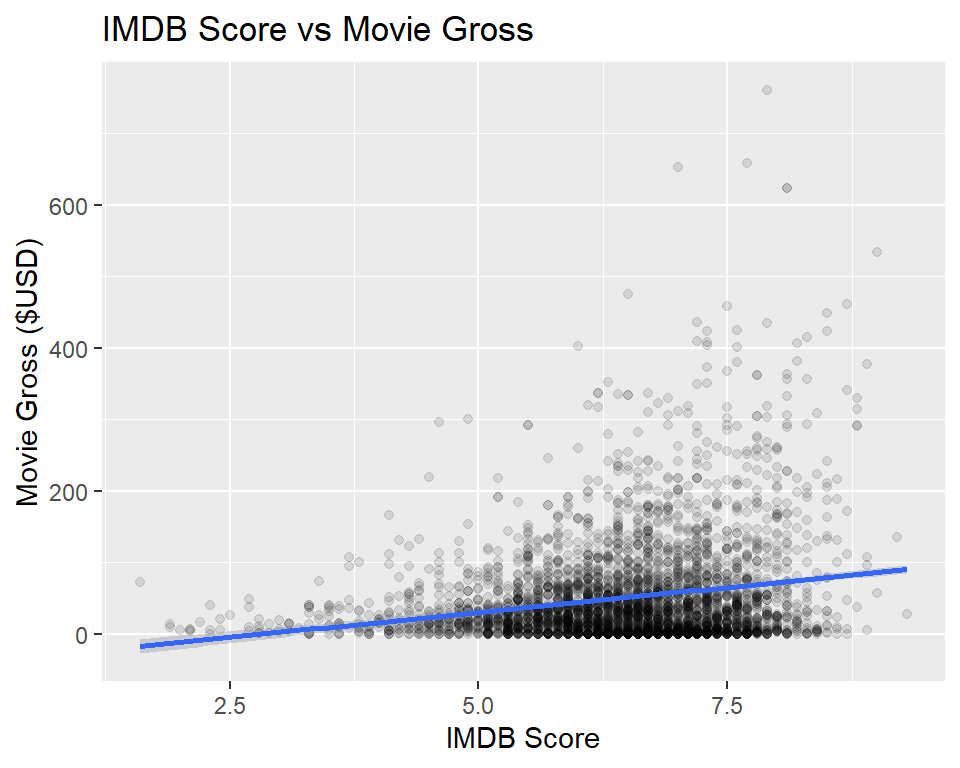

```r
ggplot(movies, aes(imdb_score, gross_M)) +
  geom_point(alpha = 0.1) +
  xlab("IMDB Score") +
  ylab("Movie Gross ($USD)") +
  labs(title = "IMDB Score vs Movie Gross") +
  geom_smooth(method="lm")
```

Given the line, there seems to be a slight positive relationship between IMDB Score and Movie Gross.

### Plot movie gross against IMDB score for James Cameron films, where the points are the movie titles.

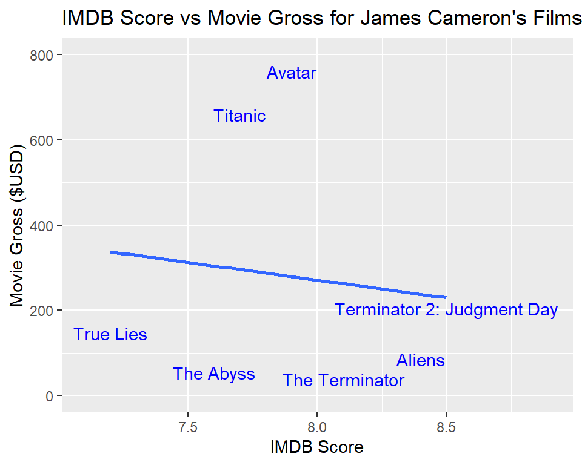

```r
ggplot(movies %>% filter(director_name == "James Cameron"),
       aes(imdb_score, gross_M)) +
  geom_text(aes(label = movie_title), color = "blue") +
  xlab("IMDB Score") +
  ylab("Movie Gross ($USD)") +
  labs(title = "IMDB Score vs Movie Gross for James Cameron's Films") +
  geom_smooth(method="lm")+
  xlim(7.1, 8.9) +
  ylim(0, 800)
```